# ZW3 no existís

Elio Campitelli

15/04/2021

La onda 3 no existe.

# 1 Raphael

La regresión de altura geopotential en el el índice de rafael da una onda tres. Eso es medio obvio; cualquier índice basado en un promedio de cualquier puntos va a tener correlación positiva cerca de los puntos usados para definirlo. La pregunta es si esto es un patrón coherente. Ya en la figura se ve algo raro. La región más correlacionada con el índice de Raphael no es ninguno de los tres puntos sino el pacífico sur central.

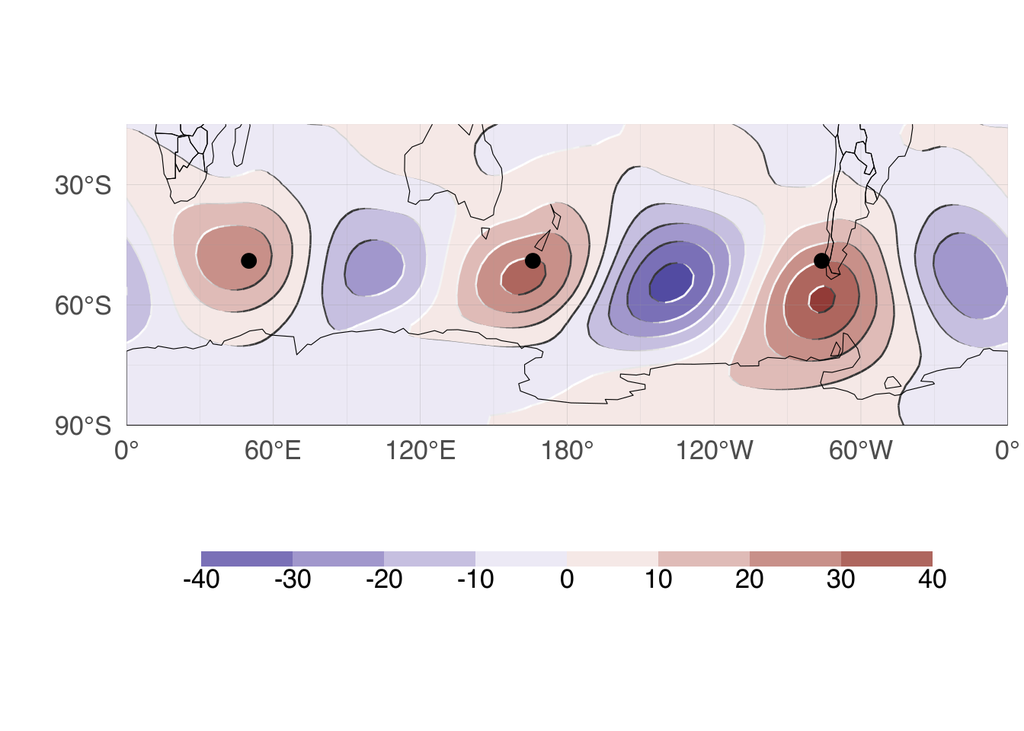

Eso se ve aún más claramente si ploteando $r^2$ en vez de el patrón de regresión.

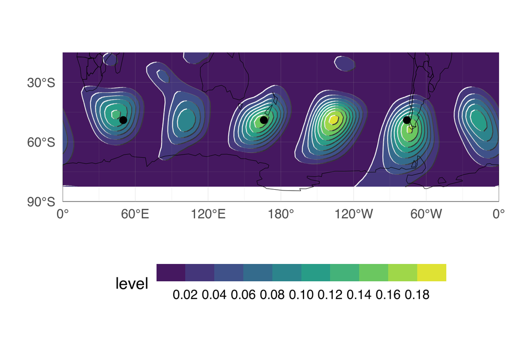

Table 1.1: Correlación entre la anomalía zonal de geopotential en los tres puntos considerados por Raphael.

| item1 | 50 | 165 | 285 |
| --- | --- | --- | --- |
| 50 | 1.000 | 0.055 | -0.095 |
| 165 | 0.055 | 1.000 | 0.113 |
| 285 | -0.095 | 0.113 | 1.000 |

La tabla muestra que correlación entre los tres puntos es básicamente nula.

Los campos de altura geopotential asociados a cada punto por separado ni se acercan a una onda 3:

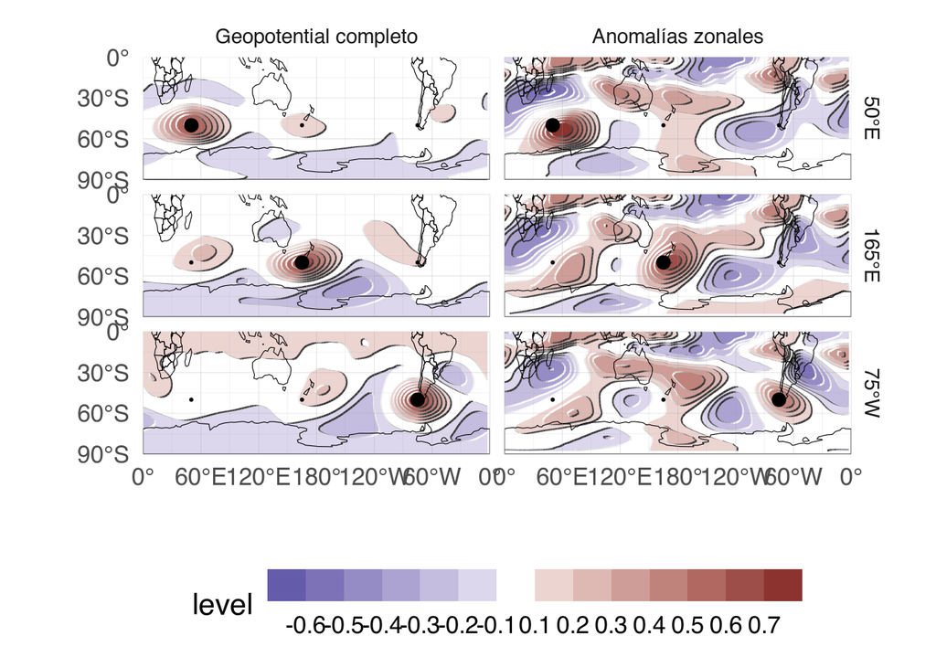

Los patrones de los sub-índices compuestos por el promedio de dos puntos tampoco tienen una onda 3.

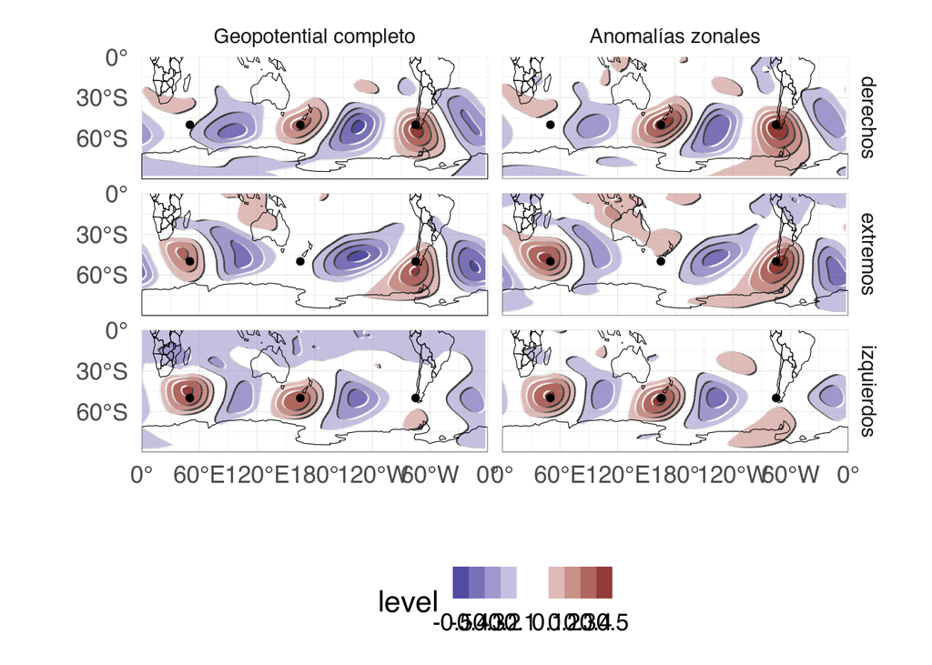

Los patrones asociados a cada punto o combinaciones de punto no son una onda 3

# 2 R2

Tabla de comparación entre campos. ZW3: Onda 3 del campo total en cada tiempo. ZW3’: Onda 3 del campo de anomalías temporales en cada tiempo. QS3: Onda 3 del campo promedio (constante en el tiempo). Z*: anomalía zonal de altura geopotencial en cada tiempo. Z*’: anomalía temporal de la anomalía zonal de altura geopotencial en cada tiempo.

| Campo | ZW3 | ZW3’ | QS3 |
| --- | --- | --- | --- |
| Z* | ✔️ | ✖️ | ✔️ |
| Z*’ | ✖️ | ✔️ | ✖️ |

La tabla muestra las posibles comparaciones y si tienen sentido o no. Las ondas 3 computadas en cada tiempo sólo tiene sentido compararlas con los campos usados para generarlas. Es decir, anomalías con anomalías (Z*’ con ZW3’) y campos totales con campos totales (Z* con ZW3). Pero ojo, que lo que busca diagnosticar el índice de Raphael no es la similitud con la ZW3 o la ZW3’ sino con la QS3, la onda 3 climatológica. Ésta en principio tiene sentido compararla con las anomalías zonales sin quitar la media climatológica, porque si estamos quitando la media, ¿por qué comparar con la climatología? Pero esto es lo que hace Raphael. Como su índice usa *anomalías* estandarizadas en los puntos donde están los máximos de la onda 3 climatológica, en realidad lo que está mirando es la correlación entre la anomalía de onda 3 y la onda 3 climatológica. Igual no es del todo loco, porque en realidad lo que se obtiene es un índice parecido a la comparación con la onda 3 total pero centrado en cero.

En lo que sigue, voy a tomar “gajos” de longitud de 120º de ancho (es decir, media longitud de onda) y calcular la correlación entre el campo de altura geopotencial y de onda 3 para cada gajo. Es decir, correlación y covarianza móvil con una ventana de 120º. Lo voy a hacer para las tres combinaciones con ✅ en la tabla anterior.

La correlación da una idea de similitud entre el campo y la onda 3 y además permite calcular la varianza explicada por la onda 3 hemisférica en cada gajo. Está afectada solamente por la diferencia de fase ente la onda 3 hemisférica y la onda 3 local. La covarianza es similar a la correlación, pero tiene en cuenta la amplitud de las anomalías de altura geopotencial. Como la hago sobre la onda 3 normalizada para tener amplitud 1, lo único que afecta la magnitud de la covarianza es la amplitud de la onda 3 geopotencial local.

Primero, un chequeo importante es ver la proporción de tiempos en los que la correlación entre las anomalías zonales de geopotencial y la onda 3 tienen correlación positiva. Para campos donde hay una onda 3 perfecta y nada más, naturalmente la correlación tendría que ser positiva el 100% de las veces en todo el domino. Para campos reales, la correlación va a tender a ser positiva cuando se compara ZW3 con Z* y ZW3’ con Z*’, porque la onda 3 en cuestión fue generada usando ese campo en particular. Pero si una parte del dominio domina y tiene una onda 3 local con mucha amplitud, podría ser que la onda 3 local de otra parte del dominio esté en otra fase y la correlación sea negativa. En el caso de la comparación entre QS3 y Z*, en principio puede ser negativa, pero en promedio, para cada latitud tiene que ser positiva.

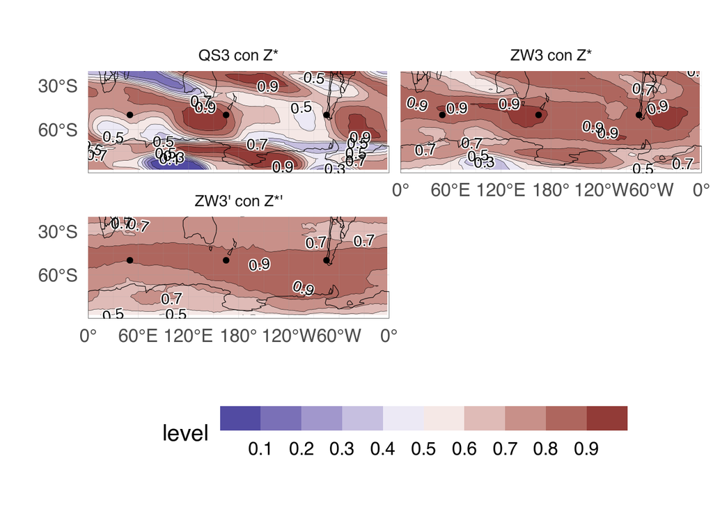

Figure 2.1: Proporción de tiempos donde cor > 0.

En la Figura 2.1 se ve la proporción de meses con correlación positiva. En la comparación de QS con Z* se ve que hay dos “hot-spots” donde la correlación es positiva más del 90% del tiempo, al sur de Australia y al sureste de Sudamérica, mientras que en el resto de las latitudes medias las correlaciones positivas se dan menos frecuentemente. En el Pacífico sur, por ejemplo, éstas se dan la mitad del tiempo, lo que equivale al azar. Esto indica que estas dos regiones son consistentemente parecidas a la onda zonal 3 climatológica mientras que las otras oscilan tanto en positivo como en negativo.

La comparando ZW3 con Z*, muestra un patrón similar a la comparación de QS3 con Z*, sólo que todos los valores son más cercanos a 1, como es de esperarse considerando que el ZW3 se construye a partir de Z*.

La comparación de ZW3’ con Z*’ también tiene valores cercanos a 1, pero se ve claramente que el Pacífico Sur es un área preferencial de mayor correlación positiva.

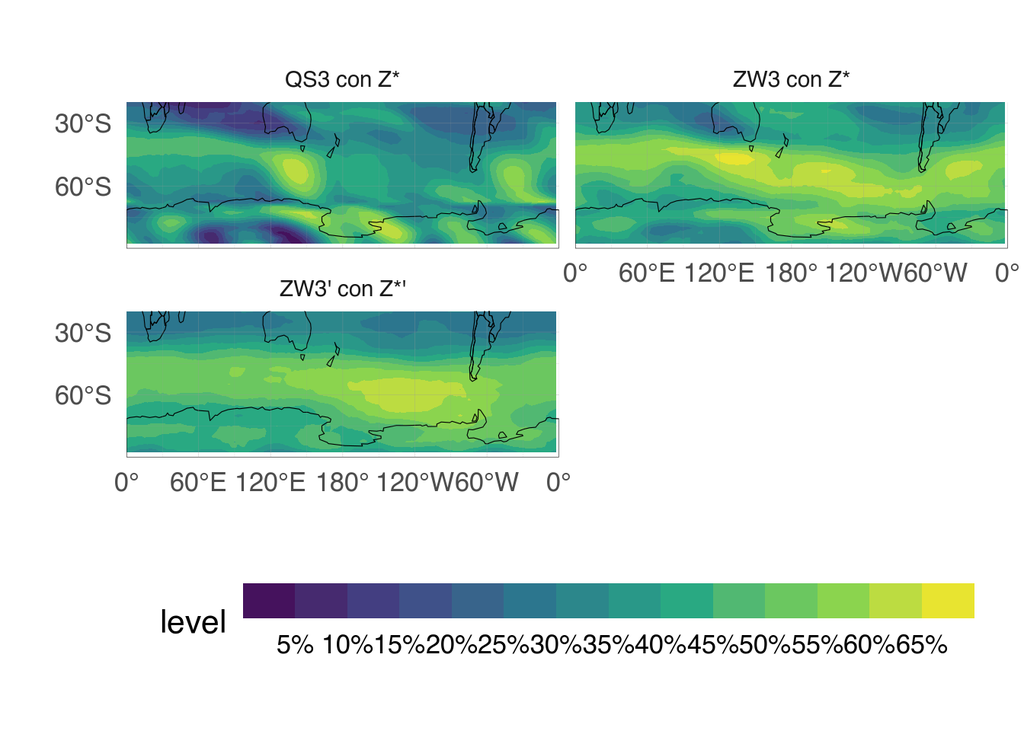

Figure 2.2: R^2 medio cuando la correlación es positiva.

La Figura 2.2 muestra la varianza explicada promedio cuando la correlación es positiva. Los patrones son similares a los de la Figurea 2.1. Las dos comparaciones que incluyen el campo medio tienen los hot-spots al sur de Australia y al sudeste de Sudamérica, mientras que las comparaciones entre anomalías tiene su máximo en el Pacífico sur.

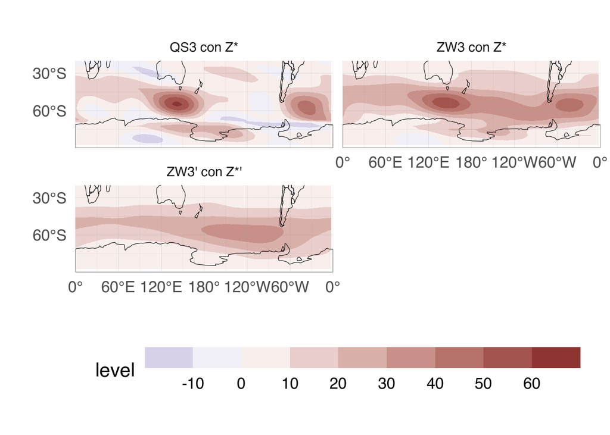

Figure 2.3: Covarianza media

En resumen, lo que se observa es que la variabilidad de la onda 3 y la onda 3 media tienen comportamientos distintos.

La onda 3 climatológica se explica y está relacionada con lo que pasa en los hot-spots de Australia y Sudamérica, pero la variación de la onda 3 no es importante en esos lugares, sino en el Pacífico Sur.

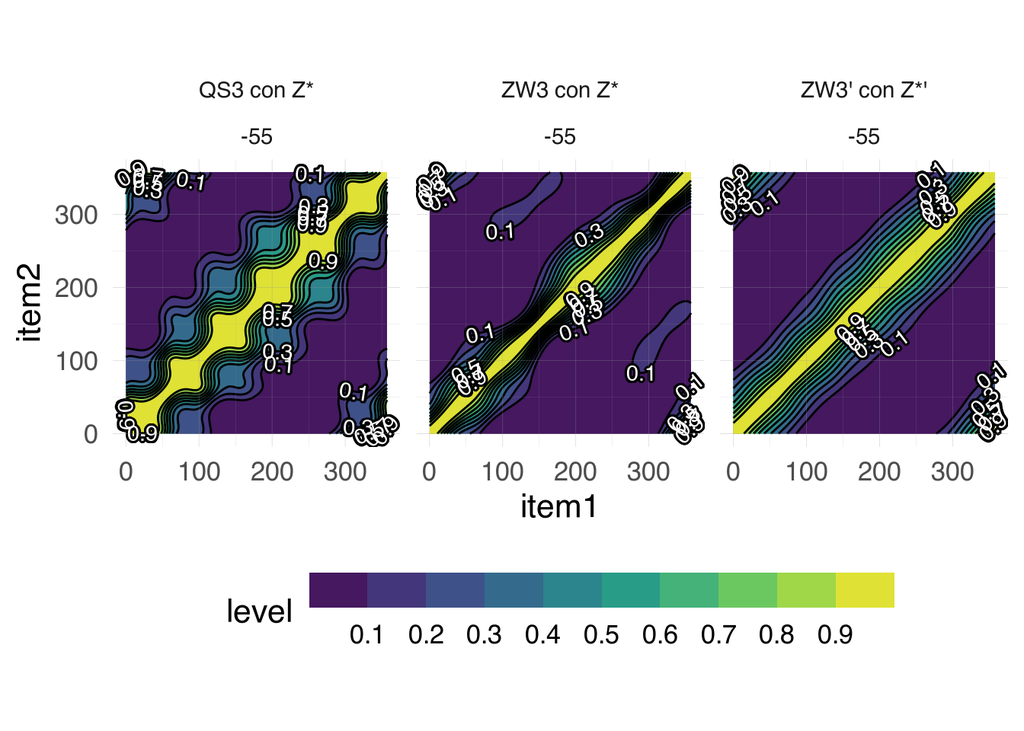

Además, la proyección de el campo explicado por la onda 3 y el campo de geopotential total computado en cada gajo co-varía muy poco entre longitudes.

# 3 Reconstrucción onda 3

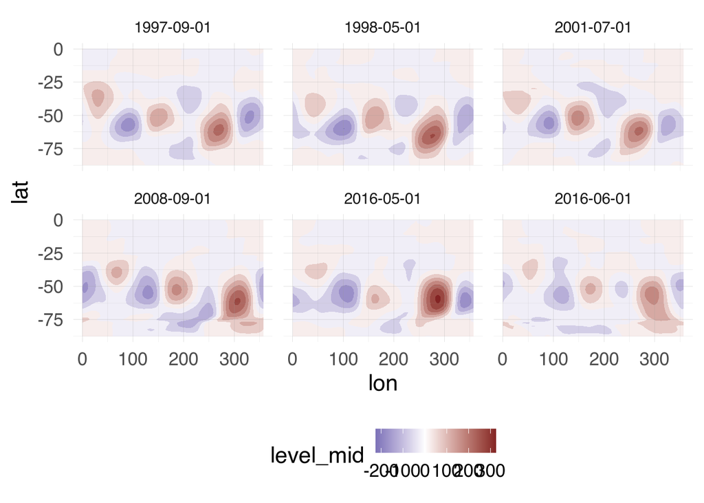

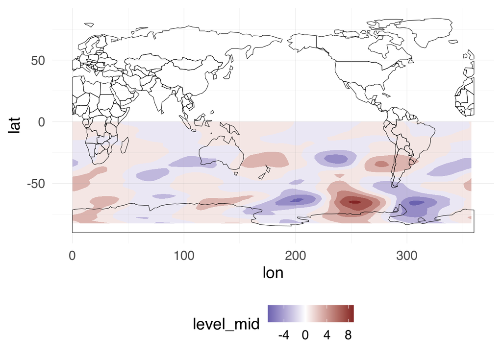

# 4 Wavelets

Amplitud de onda 3 usando wavelets no es constante sino que es máxima justamente en la región del Pacífico.

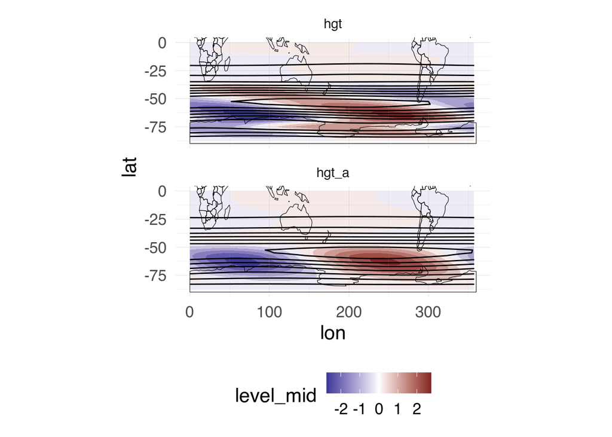

Cabe aclarar algunas deficiencias con este método. Primero, que la ventana efectiva de la Wavelet de Morlet me parece que es bastante grande, ciertamente más que los 120º que uso en el análisis anterior. Eso hace que las diferencias locales se “borroneen”, es decir, que su localización sea menos precisa.

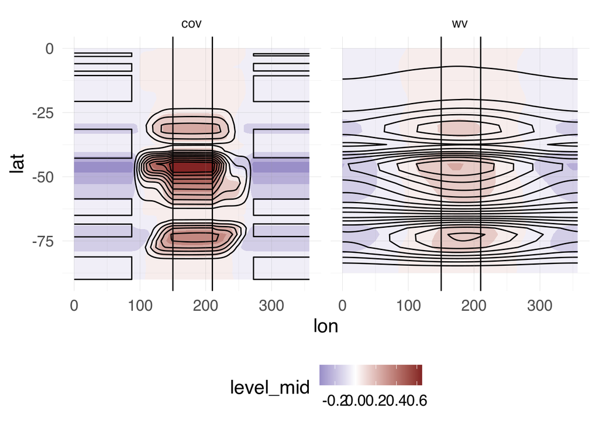

Esto se ve en la figura, que muestra cómo se comporta waveletes cuando hay una onda 3 pura únicamente entre 150°E y 150°W (líneas negras). Las líneas de contorno negras muestran la amplitud de wavelets, y puede verse que aún muy lejos de la localización de las anomalías, la amplitud de wavelets sigue siendo nada trivial. El método de la “covarianza por gajos”, en cambio, es mucho más sensible, dando valores importantes sólo cerca de las anomalías.

Otro problema de wavelets es que computa la amplitud de la onda local para cualquier fase, por lo cual no permite fijar la fase a la fase global.

Por esto, creo que es mejor usar la covarianza por gajos.